# CodingProject2

```python
# name: Hsin Yu Chen
# date: 2/23/2024
# course number: CSC647-01
# CP #2 This coding project implements classical and quantum solutions
#    for conditional bit flipping and controlled swap operations on multi-qubit systems
```

### Part 1: Conditional bit flipping.

#### Part 1a: Classical implementation

```python
def classical_bit_flip(input_data):
    for input_vector in input_data:
        lsb = input_vector & 1  # least significant bit
        msb_mask = 0b110  # flip the two most significant bits

        # If the least significant bit is set, flip the two most significant bits
        if lsb:
            output_vector = input_vector ^ 0b110
        else:
            output_vector = input_vector
        # Print the input and output vectors
        print(f"{bin(input_vector)[2:]:>03} → {bin(output_vector)[2:]:>03}")

in_data = [0b000, 0b001, 0b010, 0b011, 0b100, 0b101, 0b110, 0b111]

classical_bit_flip(in_data)
```

```
000 → 000
001 → 111
010 → 010
011 → 101
100 → 100
101 → 011
110 → 110
111 → 001
```

#### Part 1b: quantum implementation

```python
from qiskit import QuantumCircuit, transpile
from qiskit_aer import Aer
from qiskit.quantum_info import Statevector, Operator
def quantum_flip_circuit(input_value):
    circuit = QuantumCircuit(3)
    for qubit_index, bit_value in enumerate(bin(input_value)[2:][::-1]):
        if bit_value == '1':
            circuit.x(qubit_index)
    # Apply CNOT gates to flip the other two qubits based on the LSB
    circuit.cx(0, 1)
    circuit.cx(0, 2)
    return circuit

in_data = [0b000, 0b001, 0b010, 0b011,  0b100, 0b101, 0b110, 0b111]

for input_value in in_data:
    binary_representation = format(input_value, '03b')  # Format as 3-bit binary with leading zeros
    print(f"Input Value: {binary_representation}")

    qc1 = quantum_flip_circuit(input_value)
    print(qc1)
    zero = Statevector([1, 0, 0, 0, 0, 0, 0, 0])
    # Display the state vector
    state_vector = zero.evolve(Operator(qc1))
    display(Statevector(qc1).draw("latex"))
    print("\n" + "="*30 + "\n")
```

[output not shown]

[output not shown]

[output not shown]

[output not shown]

[output not shown]

[output not shown]

[output not shown]

[output not shown]

#### Discussion answers:

1.I use Controlled-NOT (CNOT) gates to entangle qubits 1 and 2 with qubit 0 acting as the control. If the LSB of the input is 1, the CNOT gates flip the states of qubits 1 and 2 based on the state of qubit 0, creating an entangled relationship between them.

2.The CNOT gate creates an entangled relationship between pairs of qubits. The state of the target qubit becomes dependent on the state of the control qubit, introducing correlation and entanglement between the two qubits.

3.When the condition (LSB of the input value being 1) exists, the Controlled-NOT (CNOT) gates act to entangle the qubits. If the LSB is 1, the state of qubits 1 and 2 becomes correlated with the state of qubit 0 through the CNOT gates, resulting in an entangled state where the measurement outcome of one qubit is dependent on the measurement outcome of another qubit. This entanglement illustrates the quantum phenomenon where the state of one qubit is inseparably linked to the state of another qubit in the system.

### Part 2: Implement “Controlled Swap” using Building Block Gates

```python
from qiskit.visualization import plot_histogram, plot_state_qsphere, plot_distribution

# Function to create controlled swap circuit
def controlled_swap_circuit(input_value):
    circuit = QuantumCircuit(3)
    for i, bit in enumerate(reversed(bin(input_value)[2:])):
        if bit == '1':
            circuit.x(i)

    # Controlled Swap gate
    circuit.cswap(2, 0, 1)
    return circuit
in_data = [0b000, 0b001, 0b010, 0b011,  0b100, 0b101, 0b110, 0b111]

for input_value in in_data:
    binary_representation = format(input_value, '03b')
    print(f"Input Value: {binary_representation}")
    qc2 = controlled_swap_circuit(input_value)
    print(qc2)

    zero = Statevector([1, 0, 0, 0, 0, 0, 0, 0])
    state_vector = zero.evolve(Operator(qc2))
    display(Statevector(qc2).draw("latex"))
    print("\n" + "="*30 + "\n")
```

```
Input Value: 000

q_0: ─X─
      │
q_1: ─X─
      │
q_2: ─■─
```

$$ |000\rangle$$

```
==============================

Input Value: 001
     ┌───┐
q_0: ┤ X ├─X─
     └───┘ │
q_1: ──────X─
           │
q_2: ──────■─
```

$$ |001\rangle$$

```
==============================

Input Value: 010

q_0: ──────X─
     ┌───┐ │
q_1: ┤ X ├─X─
     └───┘ │
q_2: ──────■─
```

$$ |010\rangle$$

```
==============================

Input Value: 011
     ┌───┐
q_0: ┤ X ├─X─
     ├───┤ │
q_1: ┤ X ├─X─
     └───┘ │
q_2: ──────■─
```

$$ |011\rangle$$

```
==============================

Input Value: 100

q_0: ──────X─
           │
q_1: ──────X─
     ┌───┐ │
q_2: ┤ X ├─■─
     └───┘
```

$$ |100\rangle$$

```
==============================

Input Value: 101
     ┌───┐
q_0: ┤ X ├─X─
     └───┘ │
q_1: ──────X─
     ┌───┐ │
q_2: ┤ X ├─■─
     └───┘
```

$$ |110\rangle$$

```
==============================

Input Value: 110

q_0: ──────X─
     ┌───┐ │
q_1: ┤ X ├─X─
     ├───┤ │
q_2: ┤ X ├─■─
     └───┘
```

$$ |101\rangle$$

```
==============================

Input Value: 111
     ┌───┐
q_0: ┤ X ├─X─
     ├───┤ │
q_1: ┤ X ├─X─
     ├───┤ │
q_2: ┤ X ├─■─
     └───┘
```

$$ |111\rangle$$

### Discussion answers:

1.I use controlled-swap gate to demonstrate an operation where the state of one qubit influences the state of another qubit.

2.The controlled-swap (cswap) gate creates a relationship where the state of one qubit (the control qubit) determines whether a swap operation is applied between two other qubits (target qubits).

3.When the condition (control qubit, qubit 2 being in the state |1⟩) is met, the controlled-swap gate exchanges the states of qubits 0 and 1. Otherwise, if qubit 2 is in the state |0⟩, qubits 0 and 1 remain unchanged. The controlled-swap gate introduces a conditional swapping behavior based on the state of the control qubit.

### Part 3: Evolving towards a specified solution state

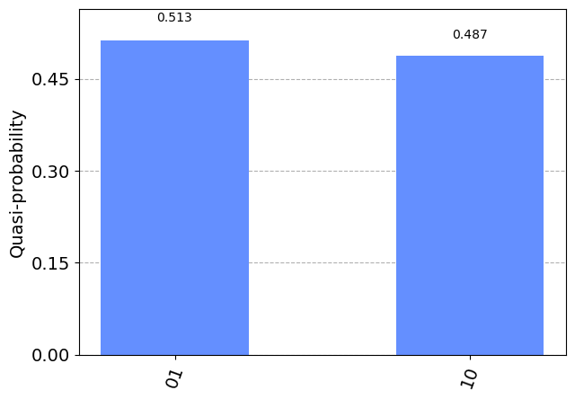

```python
qc3 = QuantumCircuit(2)

# Apply X gate
qc3.x(0)

# Apply Hadamard gate
qc3.h(1)

# Apply CNOT gate
qc3.cx(1, 0)

# Measure both qubits
qc3.measure_all()

# Simulate the circuit
simulator = Aer.get_backend('aer_simulator')
result = simulator.run(qc3, shots=1000).result()

# Get the counts
counts = result.get_counts(qc3)

# Plot the histogram
plot_distribution(counts)
```

### Discussion answers:

1. The histogram of counts represents the frequencies of different measurement outcomes obtained by running the quantum circuit multiple times. It shows how often each basis state (bitstring) is observed. In contrast, displaying the state vector would involve using Statevector to directly compute the final quantum state after the circuit is applied, without performing measurements. This would show the complex probability amplitudes for each basis state. The counts reflect the outcomes of measurements, providing a statistical distribution, while the state vector represents the quantum state before measurement, offering a complete description of the superposition and phase relationships.

2. There are 4 computational basis states in this circuit: |00⟩, |01⟩, |10⟩, and |11⟩.

3. The number of potential outcomes for a quantum circuit with N qubits is given by 2^N. For N=4 qubits, number of outcomes=2^4=16. For N=8 qubits, number of outcomes=2^8=256.